# Lab 3: COVID-19

## Question 4: Rolling Thresholds

```r
last_14_days_data <- combined_data %>%
  filter(date >= max(date) - 14)

county_stats <- last_14_days_data %>%
  group_by(county, fips) %>%
  summarize(
    total_new_cases = sum(new_cases, na.rm = TRUE),
    population = first(POPESTIMATE2021),
    new_cases_per_100k = (total_new_cases / population) * 100000
  ) %>%
  ungroup()
top_counties <- county_stats %>%
  arrange(desc(new_cases_per_100k)) %>%
  slice_head(n = 5)

top_counties %>%
  flextable() %>%
  set_caption("Top 5 Colorado Counties with the Most New Cases per 100k (Last 14 Days)")
```

| county | fips | total_new_cases | population | new_cases_per_100k |
| --- | --- | --- | --- | --- |
| Mineral | 8,079 | 8 | 929 | 861.1410 |
| Boulder | 8,013 | 2,685 | 327,084 | 820.8900 |
| Larimer | 8,069 | 2,027 | 362,747 | 558.7917 |
| Denver | 8,031 | 3,968 | 711,467 | 557.7209 |
| Jefferson | 8,059 | 2,728 | 580,703 | 469.7754 |

```r
counties_above_threshold <- sum(county_stats$new_cases_per_100k > 100)

counties_above_threshold
```

```
[1] 56
```

## Question 5: Death Toll

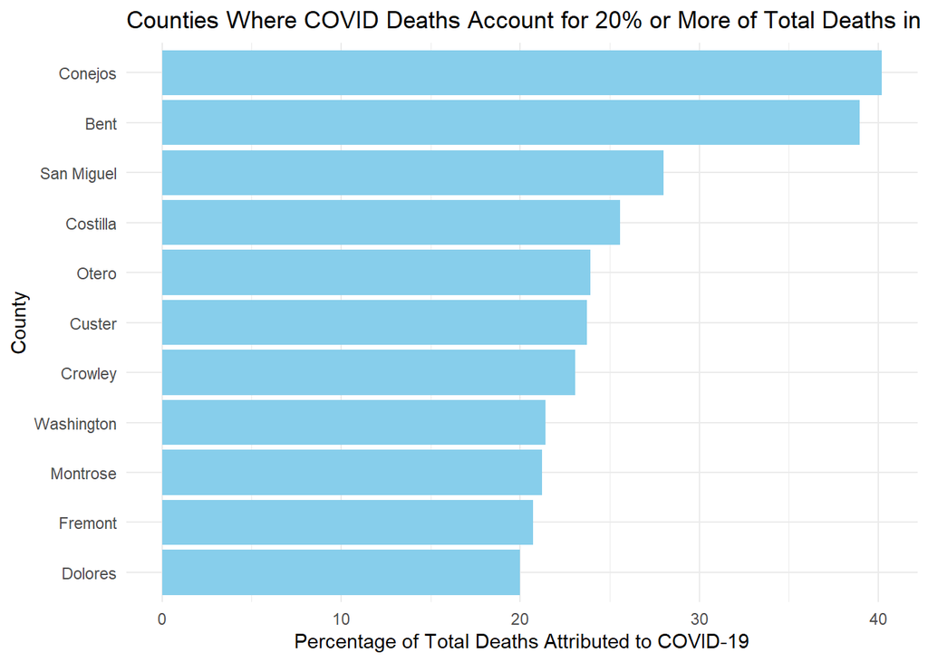

```r
covid_deaths_2021 <- combined_data %>%
  filter(date >= as.Date("2021-01-01") & date <= as.Date("2021-12-31")) %>%
  group_by(county, fips) %>%
  summarize(total_covid_deaths = sum(new_deaths, na.rm = TRUE)) %>%
  ungroup()
death_data <- covid_deaths_2021 %>%
  left_join(pop_data, by = "fips") %>%
  mutate(covid_death_percentage = (total_covid_deaths / DEATHS2021) * 100)

counties_over_20_percent <- death_data %>%
  filter(covid_death_percentage >= 20)

ggplot(counties_over_20_percent, aes(x = reorder(county, covid_death_percentage), y = covid_death_percentage)) +
  geom_bar(stat = "identity", fill = "skyblue") +
  coord_flip() +
  labs(
    title = "Counties Where COVID Deaths Account for 20% or More of Total Deaths in 2021",
    x = "County",
    y = "Percentage of Total Deaths Attributed to COVID-19"
  ) +
  theme_minimal()
```

## Question 6: Multi-state

```r
state_data_all <- covid_data

states_of_interest <- c("New York", "Colorado", "Alabama", "Ohio")

state_data_all <- state_data_all %>%
  arrange(state, date) %>%
  group_by(state) %>%
  mutate(
    new_cases = cases - lag(cases, default = 0)
  ) %>%
  ungroup()

state_data <- state_data_all %>%
  filter(state %in% states_of_interest) %>%
  group_by(state, date) %>%
  summarize(
    total_new_cases = sum(new_cases, na.rm = TRUE)
  ) %>%
  ungroup()
state_data <- state_data %>%
  arrange(state, date) %>%
  group_by(state) %>%
  mutate(
    daily_new_cases = total_new_cases - lag(total_new_cases, default = 0),
    rolling_7_day_mean = zoo::rollmean(daily_new_cases, 7, fill = NA, align = "right")
  ) %>%
  ungroup()

head(state_data)
```

```
# A tibble: 6 × 5
  state   date       total_new_cases daily_new_cases rolling_7_day_mean
  <chr>   <date>               <dbl>           <dbl>              <dbl>
1 Alabama 2020-03-13               1               1                 NA
2 Alabama 2020-03-14               1               0                 NA
3 Alabama 2020-03-15               1               0                 NA
4 Alabama 2020-03-16               0              -1                 NA
5 Alabama 2020-03-17               0               0                 NA
6 Alabama 2020-03-18               0               0                 NA
```

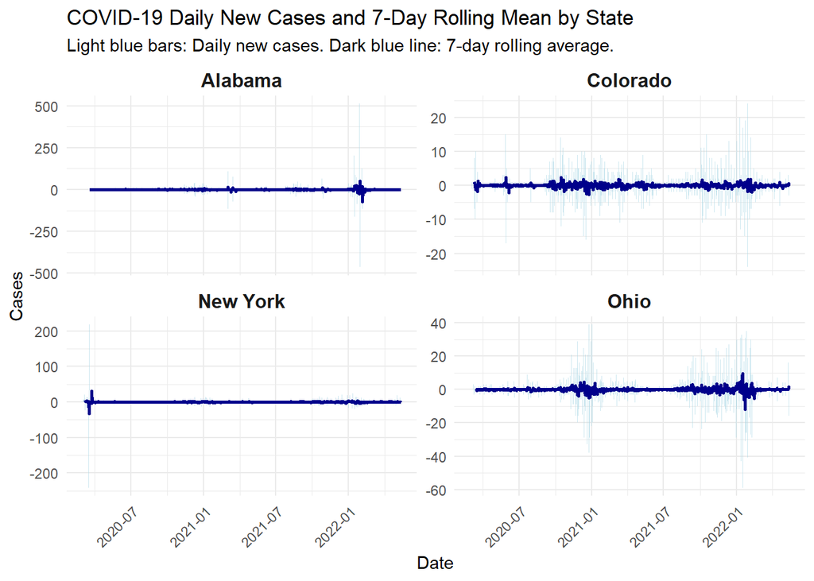

```r
ggplot(state_data, aes(x = date)) +

  geom_bar(aes(y = daily_new_cases), stat = "identity", fill = "lightblue", alpha = 0.6) +

  geom_line(aes(y = rolling_7_day_mean), color = "darkblue", size = 1) +

  facet_wrap(~state, scales = "free_y") +

  labs(
    title = "COVID-19 Daily New Cases and 7-Day Rolling Mean by State",
    subtitle = "Light blue bars: Daily new cases. Dark blue line: 7-day rolling average.",
    x = "Date",
    y = "Cases"
  ) +

  theme_minimal() +
  theme(
    axis.text.x = element_text(angle = 45, hjust = 1),
    strip.text = element_text(size = 12, face = "bold")
  )
```

Scaling by population gives a clearer picture of the intensity or severity of COVID-19’s spread in relation to the size of the population, allowing for fairer comparisons between states of different sizes. It highlights areas that may be more vulnerable relative to their population, even if their total case numbers are lower. This method is crucial for understanding where healthcare resources might be most stretched and where outbreaks may be particularly severe despite smaller total case numbers.